# R Notebook

Inzicht in de afremmen van auto’s met verschillende beginsnelheid.

```r
require("RPostgreSQL")
```

```r
drv <- dbDriver("PostgreSQL")
con <- dbConnect(drv, dbname = "research",
                 host = "metis", port = 5433,
                 user = "postgres")

fn = "C:/Users/joepk/Documents/GitHub/r_canbus/scripts/query_braking.sql"
zz <- file(fn, "r")
#q = readLines(zz)
q <- readChar(zz, file.info(fn)$size)
braking <- dbGetQuery(con, q)
close(zz)

voorbeeld <- dbGetQuery(con, "
                    SELECT value as speed, vin, time, location from canbus.data_2017
                    WHERE signalid = 191 AND vin = '03662eafcd5b8852e3663484376c027b8b7ea8b30829cae92853ba97d5d63682'
                    ")
dbDisconnect(con)
```

```
## [1] TRUE
```

```r
head(braking)
```

|  | vin | brakeon | brakeoff | dt1 | v0 | v1 | geom | t_v0 | t_v1 | dt2 |
| --- | --- | --- | --- | --- | --- | --- | --- | --- | --- | --- |
| 1 | 0130925792c6a3bacef1295cedaa00af944d8780d25337a452883e7449ab0cbb | 2017-09-21 07:43:10 | 2017-09-21 07:43:12 | 2.59 | NA | NA | 01010000204071000099EF302092DCF3405D4D7B62F2E31B41 |  |  | NA |
| 2 | 0130925792c6a3bacef1295cedaa00af944d8780d25337a452883e7449ab0cbb | 2017-09-21 07:43:15 | 2017-09-21 07:43:16 | 1.58 | NA | NA | 01010000204071000099EF302092DCF3405D4D7B62F2E31B41 |  |  | NA |
| 3 | 0130925792c6a3bacef1295cedaa00af944d8780d25337a452883e7449ab0cbb | 2017-09-21 07:43:17 | 2017-09-21 07:43:20 | 2.61 | 0.000 | 0.000 | 01010000204071000099EF302092DCF3405D4D7B62F2E31B41 | 2017-09-21 07:43:17 | 2017-09-21 07:43:17 | 0.00 |
| 4 | 0130925792c6a3bacef1295cedaa00af944d8780d25337a452883e7449ab0cbb | 2017-09-21 07:44:14 | 2017-09-21 07:44:17 | 2.60 | 28.946 | 23.918 | 010100002040710000644A08FC53F2F340A869223F6DE91B41 | 2017-09-21 07:44:16 | 2017-09-21 07:44:17 | 1.12 |
| 5 | 0130925792c6a3bacef1295cedaa00af944d8780d25337a452883e7449ab0cbb | 2017-09-21 07:44:29 | 2017-09-21 07:44:30 | 1.00 | NA | NA | 010100002040710000638E5D9D04F3F3408B055A7D24E91B41 |  |  | NA |
| 6 | 0130925792c6a3bacef1295cedaa00af944d8780d25337a452883e7449ab0cbb | 2017-09-21 07:44:31 | 2017-09-21 07:44:32 | 1.31 | 34.508 | 34.508 | 010100002040710000638E5D9D04F3F3408B055A7D24E91B41 | 2017-09-21 07:44:31 | 2017-09-21 07:44:31 | 0.00 |

Aan ieder rem-aan signaal is de eerstvolgende snelheidsmeting toegevoegd: de beginsnelheid *v[0]*. Het eerstvolgende rem-uit signaal geeft einde aan van het afremmen. De laatst gemeten snelheid voor dit signaal is *v[1]*. Remtijd (dt1) is het tijdverschil tussen rem-aan en rem-uit. Om te voorkomen dat een auto die afremt tot stilstand en bij het verkeerslicht zijn rempedaal ingedrukt houdt, enkele minuten aan het remmen is, is ook tijdverschil tussen meting v0 en v1 berekend (dt2). Doorgaans is dt2 korter dan dt1 en geeft een beter idee van de periode waarover snelheid afgenomen is.

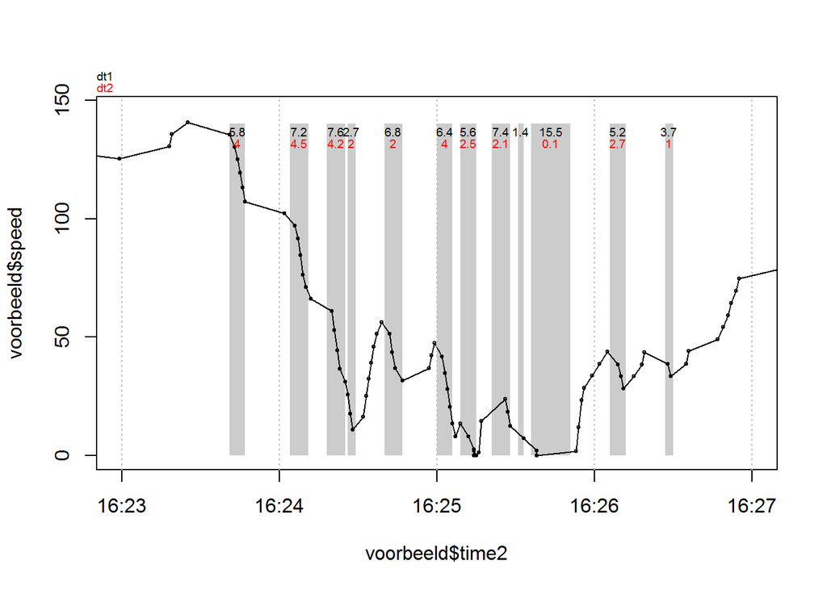

```r
# plot voor enkele auto
a = subset(braking, braking$vin == '03662eafcd5b8852e3663484376c027b8b7ea8b30829cae92853ba97d5d63682')
a$on = strptime(paste('1/1/2017',substr(a$brakeon, 12, 19)), format='%d/%m/%Y %H:%M:%S')
a$off = strptime(paste('1/1/2017',substr(a$brakeoff, 12, 19)), format='%d/%m/%Y %H:%M:%S')
voorbeeld$time2 = strptime(paste('1/1/2017',substr(voorbeeld$time, 12, 19)), format='%d/%m/%Y %H:%M:%S')


plot(voorbeeld$time2, voorbeeld$speed, type='o', pch=21, cex=0.4,
  xlim=c(as.numeric(as.POSIXct("2017-01-01 16:23:00")), as.numeric(as.POSIXct("2017-01-01 16:27:00"))), xaxt='n')

rect(xleft = a$on, xright = a$off, ytop = 140, ybottom = 0, col=rgb(0,0,0,0.2), border = NA)

r <- as.POSIXct(round(range(voorbeeld$time2), "hours"))
axis.POSIXct(1, at = seq(r[1], r[2], by = "1 min"), format = "%H:%M")
abline(v=seq(r[1], r[2], by = "1 min"), lty=3, col='grey')
text(x = a$on + 0.5*(a$off-a$on), y = 130, labels = round(a$dt1,1), cex=0.6, pos=3)
text(x = a$on + 0.5*(a$off-a$on), y = 125, labels = round(a$dt2,1), cex=0.6, pos=3, col=2)
mtext(text = 'dt2', col=2, cex=0.6, side = 3, line = 0, adj=0)
mtext(text = 'dt1', col=1, cex=0.6, side = 3, line = 0.5, adj=0)
```

Uitzetten afname in snelheid (v0-v1) als functie van remtijd (dt2), gegroepeerd op beginsnelheid (v0):

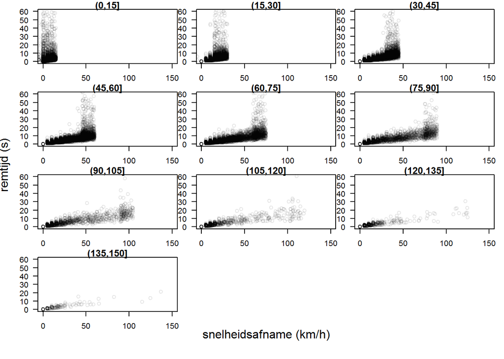

```r
braking$cut = cut(braking$v0, breaks = seq(0,150,length.out = 11))

par(mfrow=c(4,3), mar=c(2,1,1,1), oma = c(3,3,0,0))
for (cut in sort(na.omit(unique(braking$cut)))){
  x = braking[braking$cut == cut, c('v0', 'v1', 'dt2', 'cut') ]
  plot(x$v0-x$v1, x$dt2, ylim=c(0,60), col=rgb(0,0,0,0.1), main=cut, xlim=c(0,150), xaxt='n', yaxt='n')
  axis(1, lab=T)
  axis(2, lab=T, las=1)
}
mtext(text = 'snelheidsafname (km/h)', side = 1, outer = T)
mtext(text = 'remtijd (s)', side = 2, outer = T, line = 2)
```

Hypothese is dat op een weg die tegen de maximale capaciteit aan zit, auto’s vaker kort remmen om de snelheid aan te passen aan de overige weggebruikers. Bijvoorbeeld minstens 3 keer remmen binnen 5 minuten met een remtijd < 3 s en afname in snelheid < 5 km/u.

Deze selectie is eenvoudig te maken uit bovenstaande tabel.

Door ndw-lusdata in de buurt van dergelijke gevallen te bekijken voor hetzelfde tijdstip, is te achterhalen of er rond die tijd file otnstaat of niet.

tabel canbus.tmp_braking {dt1 < 3 AND v0 > 100} gevallen waar file otnstaat: ‘30bdd76cecc45261992907bae971047547622e00bda42c71bcee9564c1d8e5ab’, 2017-09-05 07:31:06.89+02 ‘7f1f426fcfa79fdc6596e0b98debfe2cc0a99d16af78f0a02f63b2ed9b4a2146’, 2017-09-12 07:19:46.93+02

gevallen waar geen file ontstaat: ‘5ec39fcc2aac8607627c319562821a7d549c4a993e862441063cdc361ff85dc8’, 2017-09-01 08:45:44.94+02 ‘cad996e7e20aae127a682f381bdaa5c44266e0d45a164965c9ee779b8830d643’, 2017-09-12 09:19:06.25+02